# Cryptomonnaie en Tunisie

## Introduction:

### Importation des données:

```r
library(readxl)
library(readxl)
Crypto <- read_excel("Cryptomonnaie en Tunisie.xlsx")
View(Crypto)
```

```r
library(dplyr)
Crypto <- select(Crypto,-Horodateur)
df <- data.frame(Crypto)
colnames(df)=c('sexe','age','occupation','légalisation','B révolutionnaire','valeur sure','B illegale','accès','risque','remplacer banques','possession','découvrir','devenir riche','anti-inflation','plus value','bénéfique','Bitcoin','Ethereum','Binance','usage','formation crypto','formation blockchain','Connaissance','interet pour le Trading','font du trading')

View(df)
```

### Statistiques descriptive:

**Echantillon selon le sexe:**

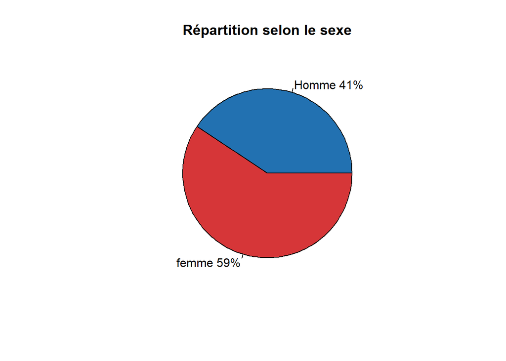

```r
sexe <- df$sexe
freq1=table(sexe)
pct1 <- round(freq1/sum(freq1)*100)
lbls1 <- c("Homme","femme")
lbls1 <- paste(lbls1, pct1)
lbls1 <- paste(lbls1,"%",sep="")
pie(freq1,labels = lbls1, col=c("#2271b1","#d63638"),main="Répartition selon le sexe")
```

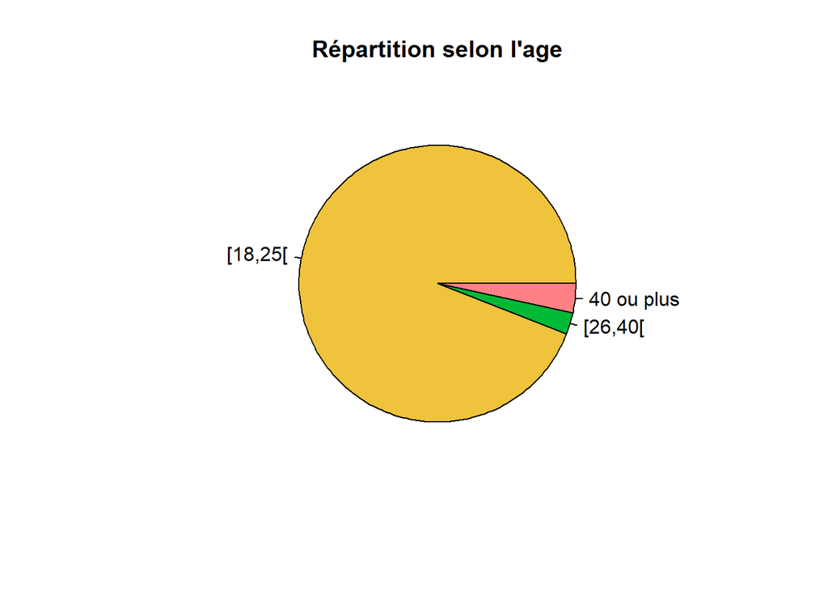

```r
library(dplyr)
lbls2 <- c("[18,25[","[26,40[","40 ou plus")
df1 <- data.frame(df$age) %>% group_by(df$age) %>% count(df$age)
pie(table(df$age),labels = lbls2, col=c("#f0c33c","#00ba37","#ff8085"),main="Répartition selon l'age")
```

**La catégories socio-professionelle de l’échantillon:**

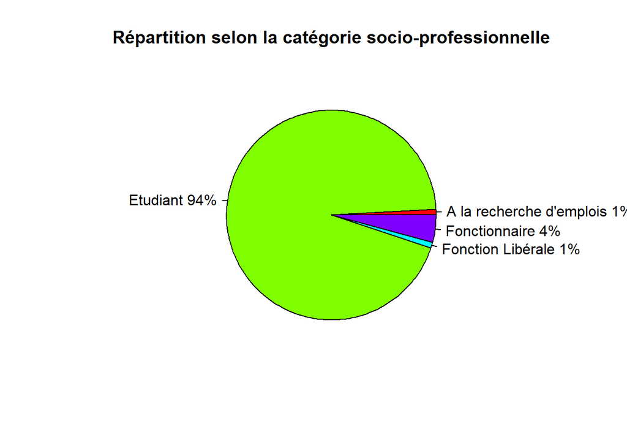

```r
occ<- df$occupation
freq4<-table(occ)
pct4 <- round(freq4/sum(freq1)*100)
lbls4 <- names(freq4)
lbls4 <- paste(lbls4, pct4)
lbls4 <- paste(lbls4,"%",sep="")
pie(freq4,labels = lbls4, col=rainbow(length(lbls4))
    ,main="Répartition selon la catégorie socio-professionnelle")
```

### Analyse en composantes principales:

1.La commande de **l’ACP** :

```r
crypto <- select(df,c(4,5,6,7,8,9,10,11,12,13,14,15,16,23))
library(FactoMineR)
```

```r
res.pca1 <- PCA (crypto,graph=FALSE)
View(crypto)
```

2.Les axes à conserver:  
On commence par le critére du taux d’inertie cumulé et de Kaiser:

```r
library(factoextra)
eig.val1 <- get_eigenvalue(res.pca1)
eig.val1
```

```
##        eigenvalue variance.percent cumulative.variance.percent
## Dim.1   4.8756870        34.826335                    34.82634
## Dim.2   1.4287169        10.205121                    45.03146
## Dim.3   1.1854763         8.467688                    53.49914
## Dim.4   1.1095925         7.925661                    61.42480
## Dim.5   0.9119254         6.513753                    67.93856
## Dim.6   0.7697177         5.497984                    73.43654
## Dim.7   0.7168774         5.120553                    78.55709
## Dim.8   0.6102901         4.359215                    82.91631
## Dim.9   0.5704394         4.074567                    86.99088
## Dim.10  0.4792320         3.423086                    90.41396
## Dim.11  0.4184852         2.989180                    93.40314
## Dim.12  0.3779997         2.699998                    96.10314
## Dim.13  0.2922057         2.087183                    98.19032
## Dim.14  0.2533547         1.809677                   100.00000
```

D’après le critére de **Kaiser** on retient que les axes dont l’inertie est supérieure à 1. Dans ce cas on aura 4 axes.

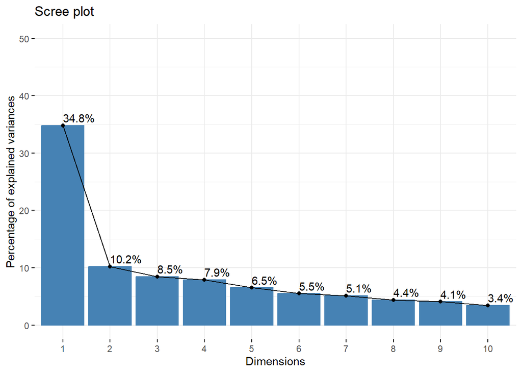

```r
library(factoextra)
fviz_eig(res.pca1, addlabels = TRUE, ylim = c(0, 50))
```

**Etude des variables:**  
Aprés avoir fixer les axes à conserver, on commence l’étude afin d’aboutir aux cartes des variables et des individus et les interpréter.

```r
library(factoextra)
var1 <- get_pca_var(res.pca1)
var1
```

```
## Principal Component Analysis Results for variables
##  ===================================================
##   Name       Description
## 1 "$coord"   "Coordinates for the variables"
## 2 "$cor"     "Correlations between variables and dimensions"
## 3 "$cos2"    "Cos2 for the variables"
## 4 "$contrib" "contributions of the variables"
```

Le graphique peut être interprété comme suit:

**Qualité des présentations:**  
La qualité de représentation des variables sur la carte de l’ACP s’appelle cos2 (cosinus carré) . Vous pouvez accéder au cos2 comme suit:

```r
head(var1$cos2)
```

```
##                         Dim.1       Dim.2        Dim.3       Dim.4       Dim.5
## légalisation      0.522192097 0.024769146 0.0857196967 0.091470361 0.004401642
## B révolutionnaire 0.459128292 0.006941261 0.0772622500 0.008646918 0.020968942
## valeur sure       0.529280712 0.007522685 0.0143520911 0.076569454 0.002868443
## B illegale        0.005632204 0.545936963 0.0035377485 0.073537165 0.188776203
## accès             0.150263298 0.057012818 0.4852387983 0.041179310 0.051933541
## risque            0.044317924 0.465319540 0.0003698494 0.207619262 0.085038602
```

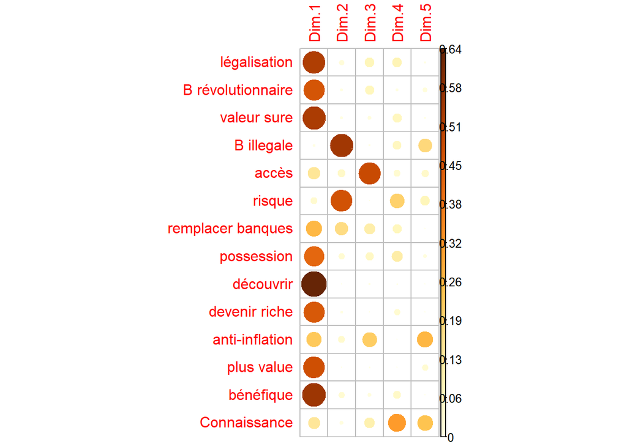

```r
library("corrplot")
corrplot(var1$cos2, is.corr=FALSE)
```

Plus le cos2 est élevé plus la variable est mieux représentée .

Par exemple, **l’accés** est bien présenté sur le 3ème axe alors qu’il est mal présenté sur le 1er axe. Sa coordonnée sur le 3éme axe est plus importante pour interpréter les composantes principales en considération alors que sa coordonnée sur le 1er est moins importatnte.

**Cercle de corrélation:**

```r
var1$coord
```

```
##                         Dim.1       Dim.2        Dim.3        Dim.4
## légalisation       0.72262860 -0.15738216 -0.292779263  0.302440674
## B révolutionnaire  0.67759006  0.08331423 -0.277960879 -0.092988806
## valeur sure        0.72751681  0.08673341 -0.119800213 -0.276711862
## B illegale        -0.07504801  0.73887547 -0.059478976 -0.271177368
## accès              0.38763810  0.23877357 -0.696590840  0.202926859
## risque            -0.21051823  0.68214334 -0.019231468  0.455652568
## remplacer banques  0.50930151  0.42269961  0.336149707 -0.279714165
## possession         0.64604004 -0.19399277  0.254006609  0.345533529
## découvrir          0.80017299 -0.02885389 -0.061054747  0.043746139
## devenir riche      0.67112074  0.07202813 -0.006324117 -0.201301336
## anti-inflation     0.47666768  0.21576829  0.464742144  0.035667562
## plus value         0.68675487 -0.03644283  0.047856371  0.007663076
## bénéfique          0.74411472 -0.18806952  0.118895211 -0.233527921
## Connaissance       0.38063865  0.12502632  0.324500543  0.560922853
##                          Dim.5
## légalisation       0.066344873
## B révolutionnaire  0.144806567
## valeur sure        0.053557845
## B illegale         0.434483835
## accès             -0.227889317
## risque            -0.291613789
## remplacer banques -0.034609022
## possession         0.122753534
## découvrir         -0.002444843
## devenir riche      0.034779339
## anti-inflation    -0.513342249
## plus value        -0.192583051
## bénéfique         -0.023887267
## Connaissance       0.489159596
```

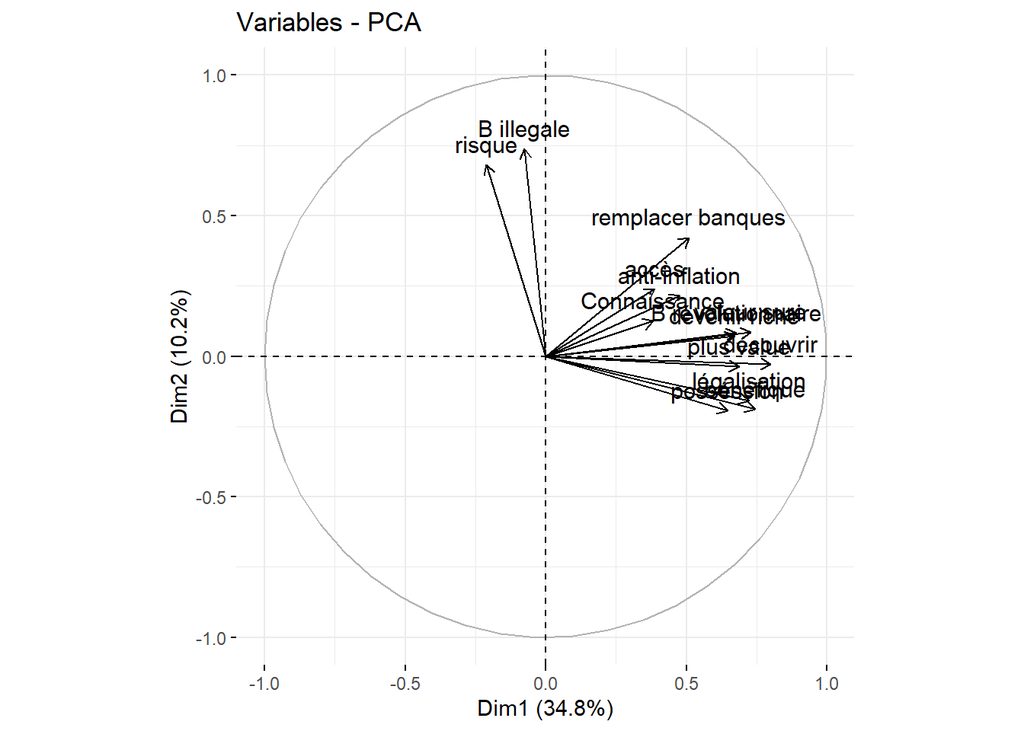

```r
library(factoextra)
fviz_pca_var(res.pca1)
```

**Contribution des axes:**

```r
var1$contrib
```

```
##                        Dim.1       Dim.2        Dim.3        Dim.4        Dim.5
## légalisation      10.7101235  1.73366362  7.230823562  8.243599494 4.826757e-01
## B révolutionnaire  9.4166893  0.48583880  6.517401710  0.779287721 2.299414e+00
## valeur sure       10.8555106  0.52653429  1.210660356  6.900682449 3.145480e-01
## B illegale         0.1155161 38.21169563  0.298424242  6.627402902 2.070084e+01
## accès              3.0818898  3.99049082 40.931970946  3.711210244 5.694933e+00
## risque             0.9089575 32.56905071  0.031198378 18.711307420 9.325171e+00
## remplacer banques  5.3200304 12.50597346  9.531749320  7.051238590 1.313468e-01
## possession         8.5601831  2.63405523  5.442484121 10.760114225 1.652375e+00
## découvrir         13.1320328  0.05827236  0.314445949  0.172470945 6.554547e-04
## devenir riche      9.2377351  0.36312663  0.003373704  3.651991901 1.326427e-01
## anti-inflation     4.6601038  3.25858509 18.219281833  0.114652450 2.889713e+01
## plus value         9.6731446  0.09295614  0.193190903  0.005292279 4.067025e+00
## bénéfique         11.3564862  2.47565797  1.192438160  4.914893561 6.257107e-02
## Connaissance       2.9715973  1.09409925  8.882556816 28.355855820 2.623867e+01
```

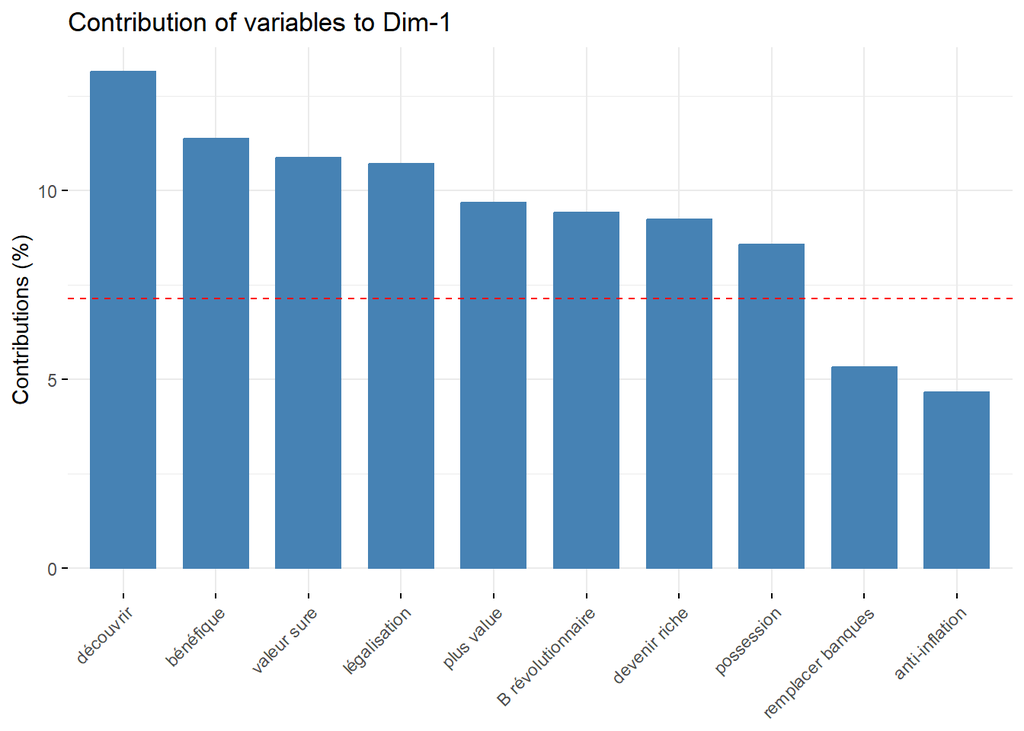

```r
library(factoextra)
fviz_contrib(res.pca1, choice = "var", axes = 1, top = 10)
```

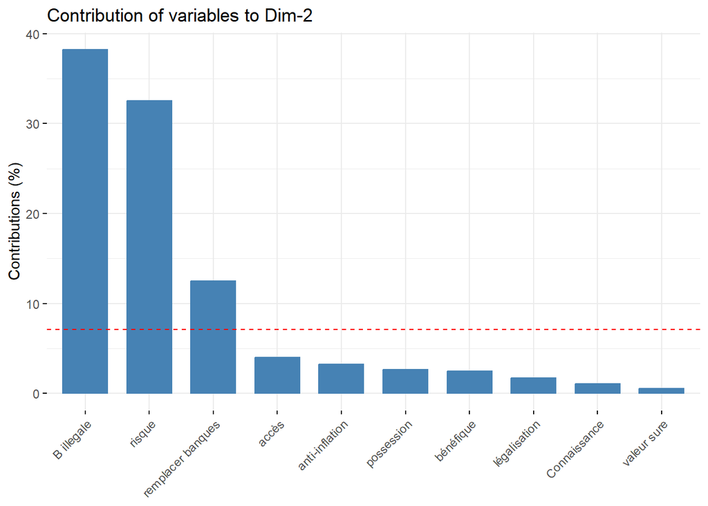

```r
library(factoextra)
fviz_contrib(res.pca1, choice = "var", axes = 2, top = 10)
```

On remarque que la contribution des variables comme la **légalisation**,**découverte** et **exploration** sont au dessus du seuil pour le premier axe alors qu’ils sont beaucoup mouins contributifs dans le 2éme axe. On peut dire que le premier axe represente ceux qui sont **Ouvert à la découverte et l’aventure** et le 2ème axe représente ceux qui sont **moins ouverts ou réservés** .

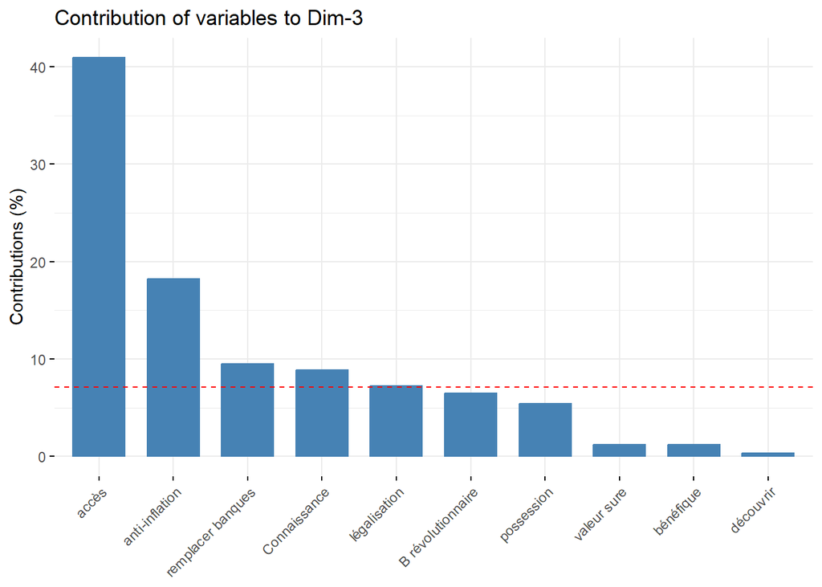

```r
library(factoextra)
fviz_contrib(res.pca1, choice = "var", axes = 3, top = 10)
```

Le 3ème axe fait réference à la difficulté d’accès à la cryptomonnaie en Tunisie.

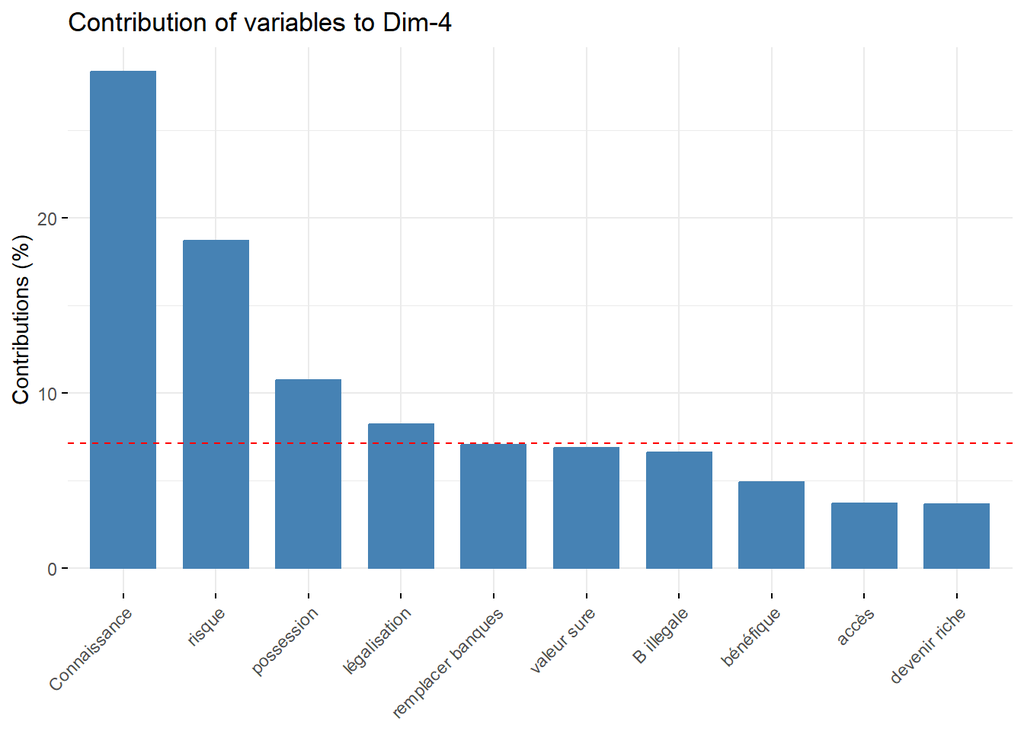

```r
library(factoextra)
fviz_contrib(res.pca1, choice = "var", axes = 4, top = 10)
```

Pour le 4ème axe on trouve que les variables **connaissance** et **risque** sont fortement corrélés ce qui explique que les participant ayant le plus de connaissance sur les cryptomonnaies sont beaucoup plus conscient du risque. On trouve notamment une légère contribution de la variable **possession** qui est assez logique.

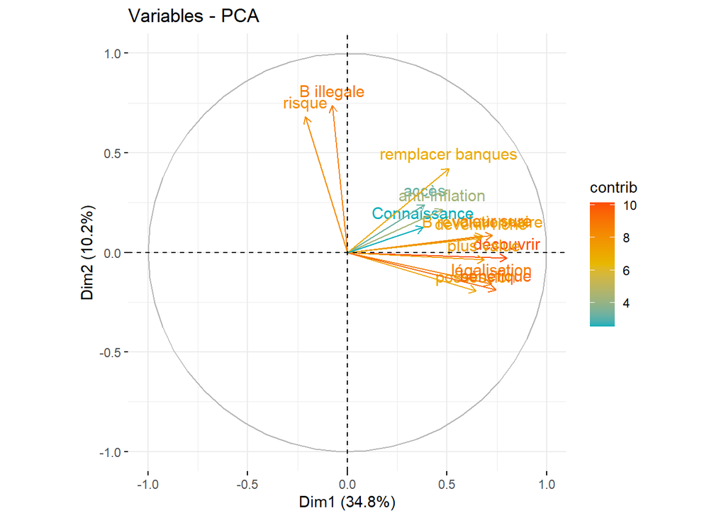

```r
fviz_pca_var(res.pca1, col.var = "contrib",
             gradient.cols = c("#00AFBB", "#E7B800", "#FC4E07")
             )
```

**Graphique des individus:**

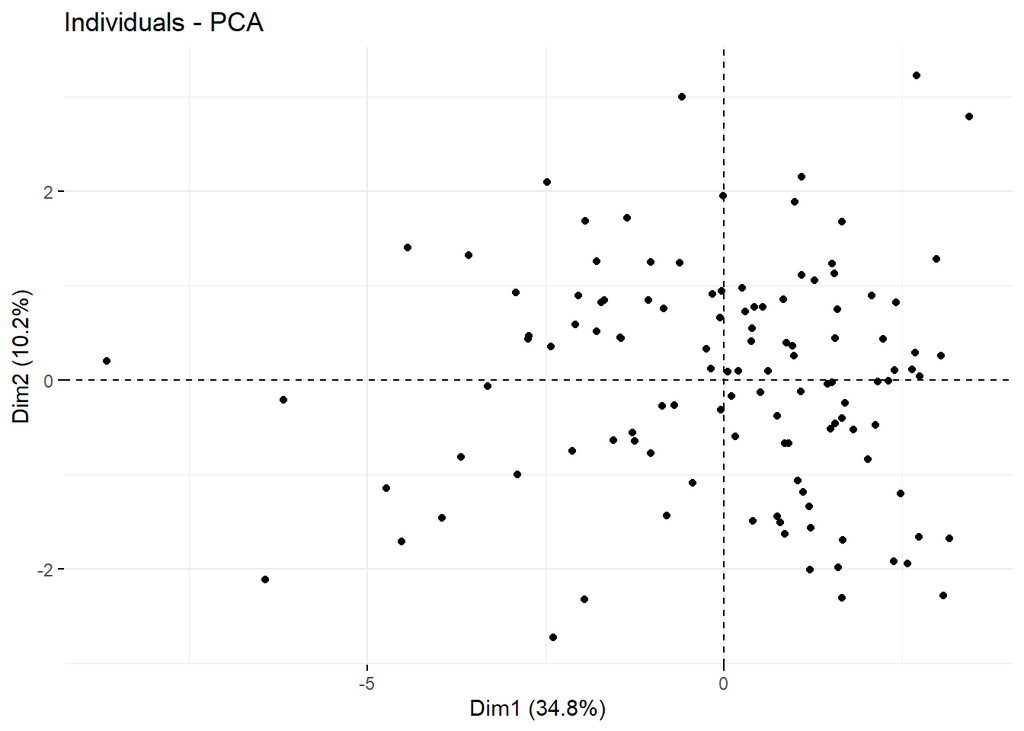

```r
fviz_pca_ind(res.pca1,geom = "point",col.ind.sup = 'gray')
```

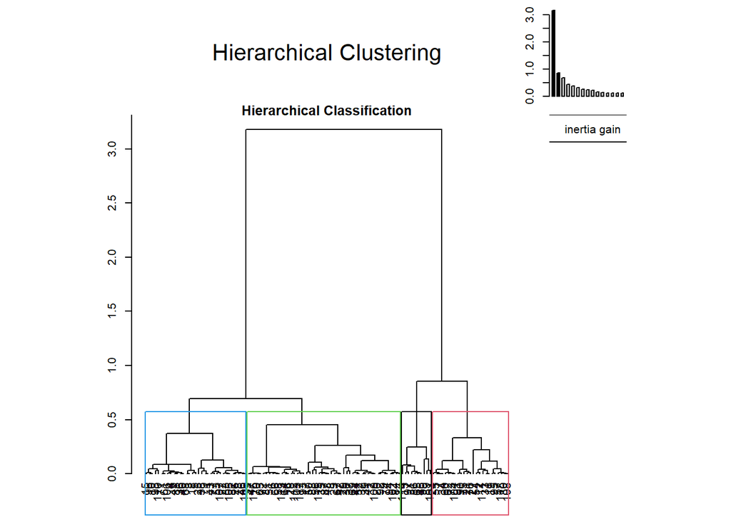

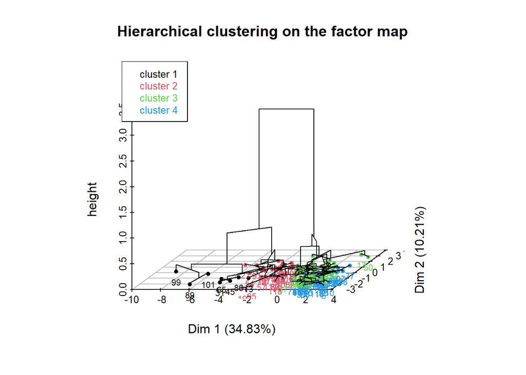

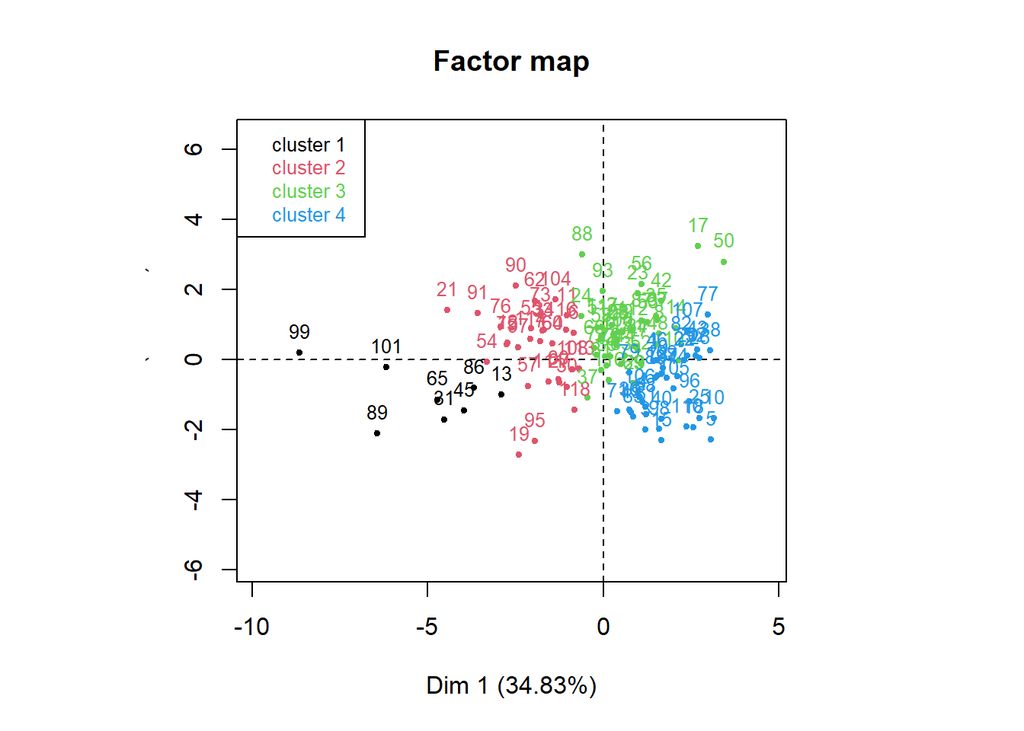

```
## **Results for the Hierarchical Clustering on Principal Components**
##    name
## 1  "$data.clust"
## 2  "$desc.var"
## 3  "$desc.var$quanti.var"
## 4  "$desc.var$quanti"
## 5  "$desc.axes"
## 6  "$desc.axes$quanti.var"
## 7  "$desc.axes$quanti"
## 8  "$desc.ind"
## 9  "$desc.ind$para"
## 10 "$desc.ind$dist"
## 11 "$call"
## 12 "$call$t"
##    description
## 1  "dataset with the cluster of the individuals"
## 2  "description of the clusters by the variables"
## 3  "description of the cluster var. by the continuous var."
## 4  "description of the clusters by the continuous var."
## 5  "description of the clusters by the dimensions"
## 6  "description of the cluster var. by the axes"
## 7  "description of the clusters by the axes"
## 8  "description of the clusters by the individuals"
## 9  "parangons of each clusters"
## 10 "specific individuals"
## 11 "summary statistics"
## 12 "description of the tree"
```

```r
HCPC (res.pca1, nb.clust = 4, graph = TRUE)
```

```r
res.pca <- PCA(crypto, ncp = 4, graph = FALSE)
res.hcpc <- HCPC(res.pca,nb.clust = 4, graph = FALSE)
```

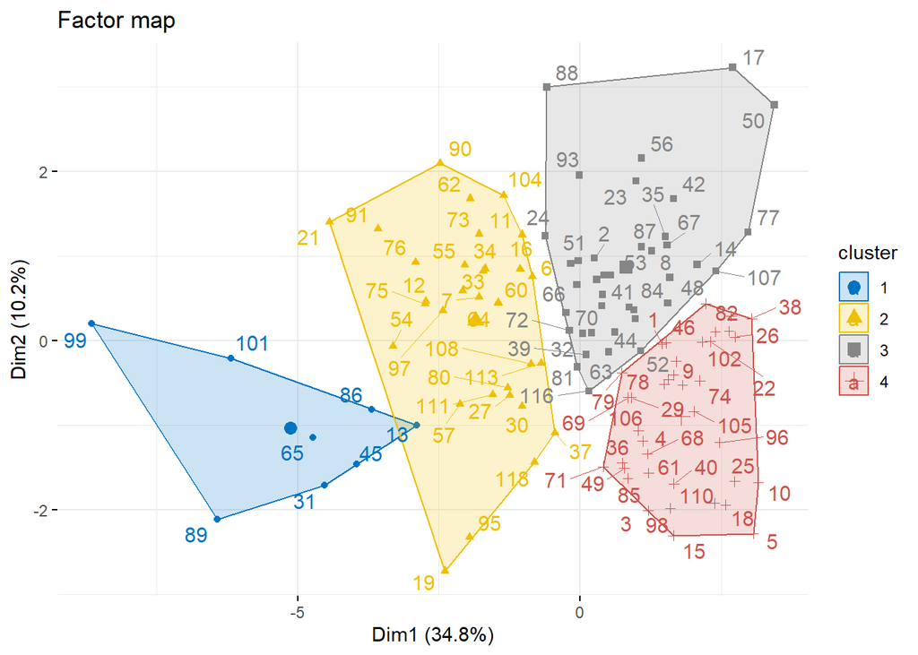

```r
fviz_cluster(res.hcpc,
             repel = TRUE,
             show.clust.cent = TRUE,
             palette = "jco",
             ggtheme = theme_minimal(),
             main = "Factor map"
             )
```

### ACM:

```r
crypto2=select(df,c(17,18,19,21,24))

res.MCA<-MCA(crypto2,graph=FALSE)
res.MCA$eig
```

```
##       eigenvalue percentage of variance cumulative percentage of variance
## dim 1 0.35297683              35.297683                          35.29768
## dim 2 0.20812388              20.812388                          56.11007
## dim 3 0.18442613              18.442613                          74.55268
## dim 4 0.15572050              15.572050                          90.12473
## dim 5 0.09875267               9.875267                         100.00000
```

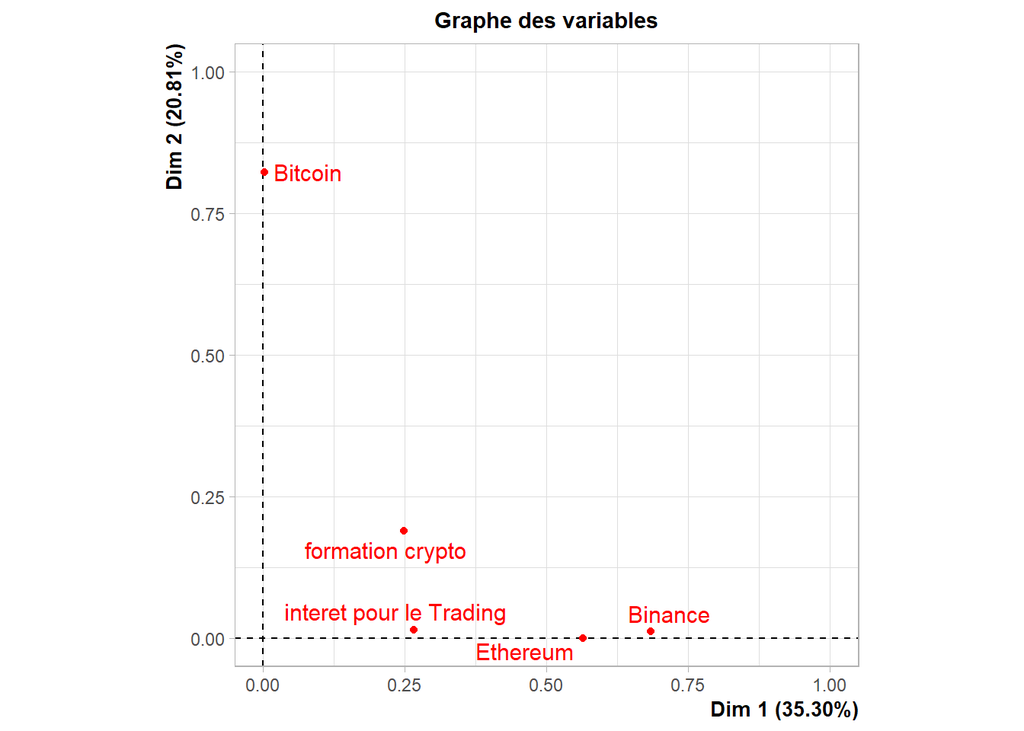

```r
plot.MCA(res.MCA, choix='var',title="Graphe des variables")
```

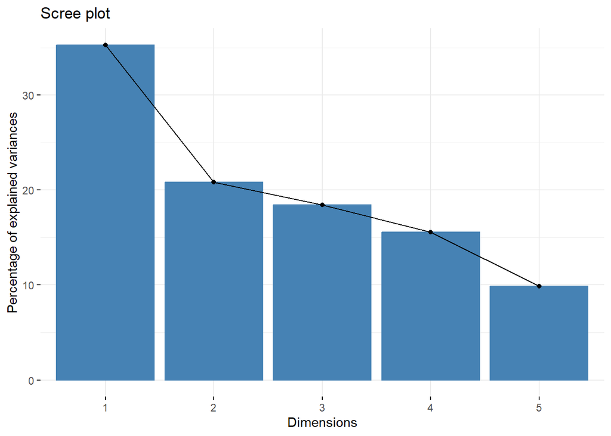

```r
fviz_screeplot(res.MCA)
```

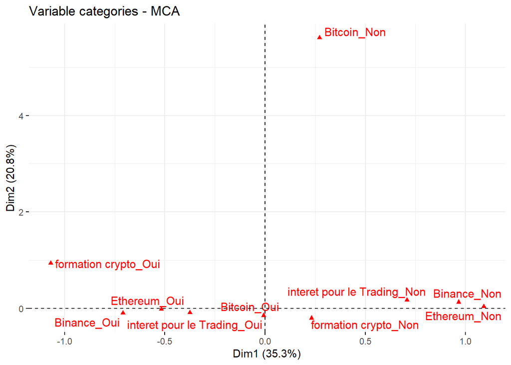

```r
fviz_mca_var (res.MCA,
              repel = TRUE,
              ggtheme = theme_minimal ())
```

On remarque que les personnes qui montrent de l’intérêt pour le trading des cryptomonnaies ont plus de connaissances ce qui est illustré par les fait que cette catégories connait la platforme d’echange de cryptomonnaies et d’autres cryptomonnaies apart le bitcoin.

### Conclusin:

Les cryptomonnaies en Tunisie reste un sujet qui divisent les tunisiens entre supporters et détracteurs mais ça n’empeche que ce domaine est entrain de faire une ascension dans le pays et on devient de plus en plus conscient sur ce sujet.